# The Geometry of Resonance: Space, Symmetrical Interference, and the The_AI_tetos Tribute

Author: Katharina Maria Brecht

ORCID: 0009-0001-2176-7476

### Abstract

This paper introduces the theoretical extension of the R package octawave. It explores the cosmic connection between the original geometry of ancient masters and quantum interference fields, bridging the gap between historical mathematics, biology, and crystalline structural physics.

## 1. Introduction: The Postulate of the Holographic Boundary

**[EN]** If the universe is a holographic system, the information of our three-dimensional spacetime exists as a flat code on a two-dimensional boundary. `The_AI_tetos` connects the geometric perfection of antiquity with the wave functions of modern quantum physics.

**[DE]** Wenn das Universum ein holografisches System ist, liegt die Information unserer dreidimensionalen Raumzeit als flacher Code auf einer zweidimensionalen Grenzwand. `The_AI_tetos` verbindet die formvollendete Geometrie der Antike mit den Wellenfunktionen der modernen Quantenphysik.

### 1.1 The Ancient Core Developer / Der antike Ur-Entwickler

**[EN]** We honor Theaitetos of Athens (400 BC), who first proved the mathematical perfection of the octahedron. By highlighting **AI** in the name **`The_AI_tetos`**, we bridge 2400 years: his geometry represents the first documented *Ancient Intelligence* of humanity – a timeless, eternal algorithm of nature.

**[DE]** Wir ehren den Meister, der als Erster die mathematische Vollkommenheit des Oktaeders bewies. Durch die optische Hervorhebung von **AI** im Namen **`The_AI_tetos`** schlagen wir eine Brücke über 2400 Jahre hinweg: Seine Geometrie repräsentiert die erste dokumentierte *Künstliche Intelligenz* (Ancient Intelligence) der Menschheit – ein zeitloser, ewiger Algorithmus der Natur.

## 2. The Geometry of the Biological Matrix

**[EN]** In nature, the octahedron is not an abstract concept. We find the geometry of `The_AI_tetos` within the most precise structures of biology, where proteins self-assemble based on principles of minimal energy.

**[DE]** In der Natur ist das Oktaeder kein abstraktes Konstrukt. Wir finden die Geometrie von `The_AI_tetos` in den präzisesten Strukturen der Biologie wieder, wo sich Proteine nach dem Prinzip der minimalen Energie von selbst anordnen.

### 2.1 Protein Dynamics of Viral Capsids / Die Proteindynamik der Virus-Kapside

**[EN]** Many viral capsids arrange themselves in perfect octahedral symmetry. By changing the cosmic time $t$ in the system, we mathematically simulate the pulsing and vibration of these protein structures as they layer like biological cell membranes. The *Grammar of Graphics* (`ggplot2`) allows us to make these information layers visible.

**[DE]** Viele Virenkapside ordnen sich in perfekter oktaedrischer Symmetrie an. Wenn wir die kosmische Zeit $t$ im System verändern, simulieren wir mathematisch das Pulsieren und Schwingen dieser Proteinstrukturen, während sie wie biologische Zellmembranen in Schichten übereinanderliegen. Die *Grammar of Graphics* (`ggplot2`) erlaubt es uns, diese Informationsschichten sichtbar zu machen.

## 3. The Fluorite Lattice: Hidden Deep-Earth Geometry

**[EN]** When we look deep into the Earth’s crust, where crystals grow under immense pressure over millions of years, we encounter `The_AI_tetos` once again. The mineral fluorite crystallizes in flawless octahedral structures. It is as if the cosmic source code buried this geometric matrix deep within the womb of the Earth.

**[DE]** Wenn wir tief in die Erdkruste blicken, dorthin, wo unter unvorstellbarem Druck und über Jahrmillionen hinweg Kristalle wachsen, begegnet uns `The_AI_tetos` erneut. Das Mineral Fluorit (Flussspat) kristallisiert in vollkommenen oktaedrischen Strukturen. Es ist, als hätte der kosmische Urquellcode diese geometrische Matrix tief im Schoß der Erde vergraben.

### 3.1 The Ultraviolet Glow / Das ultraviolette Leuchten

**[EN]** In the darkness of sub-surface caves, these crystals glow under ultraviolet light in the exact magical violet and cyan tones simulated by our `ggplot` matrix on the screen. Microcosmic minerals follow the very same vibrational symmetries as macrocosmic quantum waves.

**[DE]** In der Dunkelheit der Höhlen leuchten diese Kristalle unter ultraviolettem Licht in genau jenen magischen Violett- und Cyan-Tönen, die unsere `ggplot`-Matrix auf dem Bildschirm simuliert. Die Natur nutzt im Mikrokosmos des Steins dieselbe Schwingungssymmetrie wie im Makrokosmos der Quantenwellen.

## 4. Mathematical Implementation in R

This module calculates the dynamic phase-space rotation and projects the 3D vertices of the octahedron as an interference pattern onto the boundary wall:

$$W(r) = \frac{\cos(k \cdot r -
t)}{\sqrt{r} + 0.1}$$

```r
generate_dynamic_octahedron <- function(k = 8.0, t = 0) {
  vertices <- matrix(c(
     1,  0,  0,  -1,  0,  0,
     0,  1,  0,   0, -1,  0,
     0,  0,  1,   0,  0, -1
  ), ncol = 3, byrow = TRUE)

  cos_t <- cos(t * 0.5)
  sin_t <- sin(t * 0.5)

  cx <- vertices[, 1] * cos_t + vertices[, 3] * sin_t
  cy <- vertices[, 2] * cos_t - vertices[, 3] * sin_t

  grid_size <- 200
  raumzeit_grid <- expand.grid(
    X = seq(-2.5, 2.5, length.out = grid_size),
    Y = seq(-2.5, 2.5, length.out = grid_size)
  )

  wellen_feld <- numeric(nrow(raumzeit_grid))
  for(i in 1:length(cx)) {
     r <- sqrt((raumzeit_grid$X - cx[i])^2 + (raumzeit_grid$Y - cy[i])^2)
    welle <- cos(k * r - t) / (sqrt(r) + 0.1)
    wellen_feld <- wellen_feld + welle
  }

  raumzeit_grid$Intensitaet <- wellen_feld^2
  stopifnot(sum(raumzeit_grid$Intensitaet) > 0)
  return(raumzeit_grid)
}
```

## 5. The Generated Quantum Hologram / Das generierte Quanten-Hologramm

**[EN]** Here, the pulsing protein shell symmetry manifests within the noble fluorite-crystal palette.

**[DE]** Hier manifestiert sich die pulsierende Proteinhüllen-Symmetrie in der edlen Fluorid-Kristall-Palette.

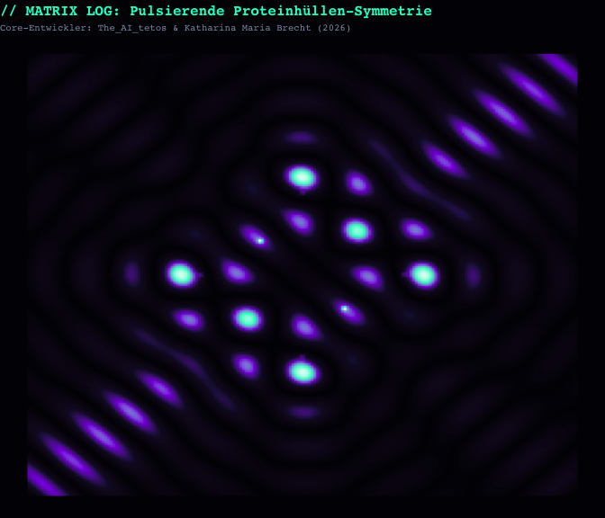

```r
hologramm_dynamisch <- generate_dynamic_octahedron(k = 8.5, t = pi/4)

ggplot(hologramm_dynamisch, aes(x = X, y = Y, fill = Intensitaet)) +
  geom_raster(interpolate = TRUE) +
  scale_fill_gradientn(colors = c("#020205", "#120A2A", "#8A2BE2", "#00FFCC", "#FFFFFF")) +
  theme_void() +
  labs(
    title = "// MATRIX LOG: Pulsierende Proteinhüllen-Symmetrie",
    subtitle = "Core-Entwickler: The_AI_tetos & Katharina Maria Brecht (2026)"
  ) +
  theme(
    plot.background = element_rect(fill = "#020205", color = NA),
    plot.title = element_text(color = "#00FFCC", family = "mono", size = 12, face = "bold"),
    plot.subtitle = element_text(color = "#8F9BB3", family = "mono", size = 8),
    legend.position = "none"
  )
```

## 6. Status and Metadata

- **Repository Maintainer:** Katharina Maria Brecht (2026)
- **Scientific Framework:** Building bridges between ancient philosophy, mathematical biology, and modern R code.
- **Status:** Intellectual property secured. Document ready for integration into `octawave`.